# 入試20180225

ryamada

2018年2月26日

# 1 0でない実数a,b,cは次の条件(i)と(ii)を満たしながら動くものとする。

1. $1+c^2 \le 2 a$
2. 2つの放物線 $C_1: y = ax^2$ と$C_2: y = b(x-1)^2 +c$ は接している

ただし、2つの曲線が接するとは、ある共有点におおいて共通の接線をもつことであり、その共有点を接点という

1. $C_1$と$C_2$の接点の座標をaとcを用いて表せ
2. $C_1$と$C_2$の接点が動く範囲を求め、その範囲を図示せよ

a,b,cを適当において、図を描いてみる

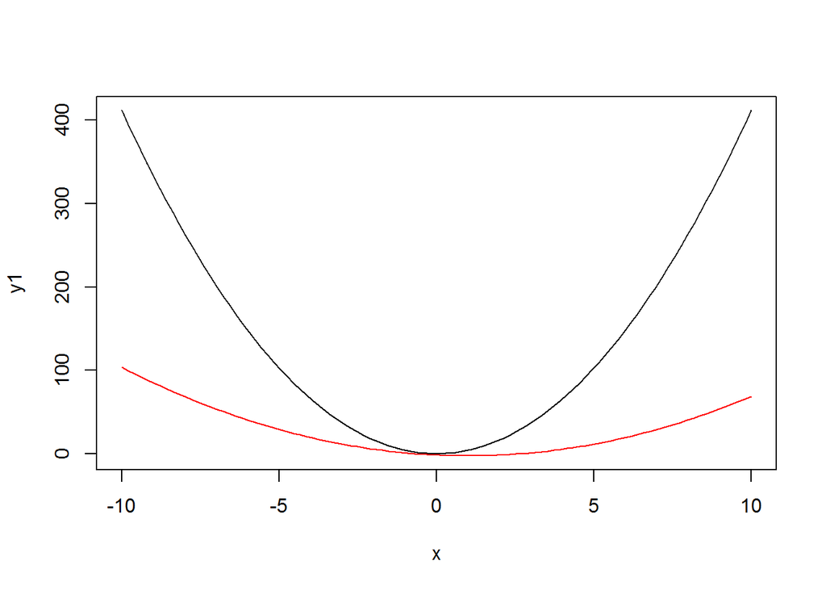

```r
# a,b,cを適当において、図を描いてみる

b. <- rnorm(1) * 2
c. <- rnorm(1) * 2
a. <- (1+c.^2)/2 + runif(1)
x <- seq(from=-10,to=10,length=100)
y1 <- a. * x^2
y2 <- b.*(x-1)^2+c.

plot(x,y1,type="l",ylim=range(c(y1,y2)))
points(x,y2,type="l",col=2)
```

共通接線を持つという条件から、$y1-y2=ax^2-(b(x-1)^2+c)=0$がx軸に接する。 その条件をa,b,cにあてはめると、$b=-\frac{ac}{a-c)}$。

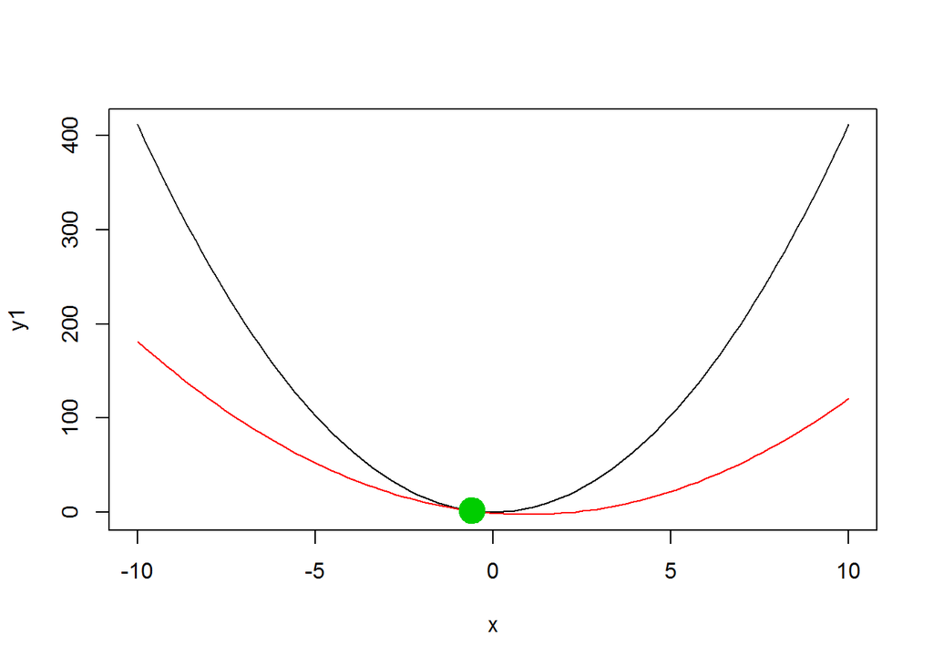

```r
b. <- -a.*c./(a.-c.)
y2. <- b.*(x-1)^2+c.
u <- c./a.
v <- c.^2/a.
plot(x,y1,type="l",ylim=range(c(y1,y2.)))
points(x,y2.,type="l",col=2)
points(u,v,pch=20,col=3,cex=4)
```

a,cをいろいろに変えて描く。

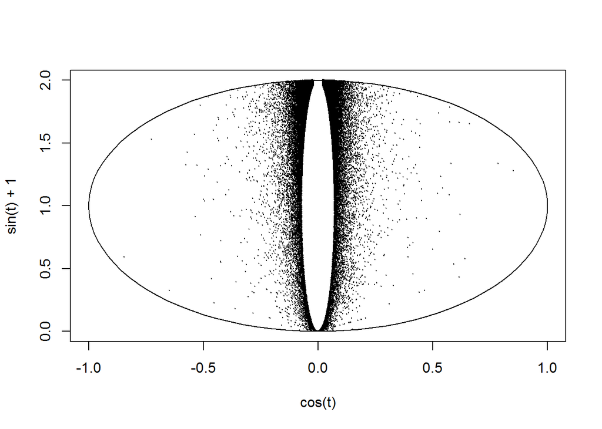

```r
c. <- seq(from=-100,to=100,length=1000)


#plot(c./a.,c.^2/a.)
t <- seq(from=0,to=2*pi,length=100)
plot(cos(t),sin(t)+1,type="l")
for(i in 1:100){
  a. <- (1+c.^2)/2 + runif(length(c.))*100
  points(c./a.,c.^2/a.,pch=20,cex=0.1)
}
```

# 2 $n^3-7n +9$ が素数になるような整数nをすべて求めよ

素数を列挙する関数を使う。

```r
#install.packages("primes")
library(primes)
help(primes)
```

```
## starting httpd help server ... done
```

```r
generate_primes(max=100)
```

```
##  [1]  2  3  5  7 11 13 17 19 23 29 31 37 41 43 47 53 59 61 67 71 73 79 83
## [24] 89 97
```

```r
is_prime(5)
```

```
## [1] TRUE
```

```r
is_prime(9)
```

```
## [1] FALSE
```

$y = x^3-7x +9$の曲線を描いた上で、整数について対応する値が素数かどうかを確認し、素数か否かで色を変えてプロットする

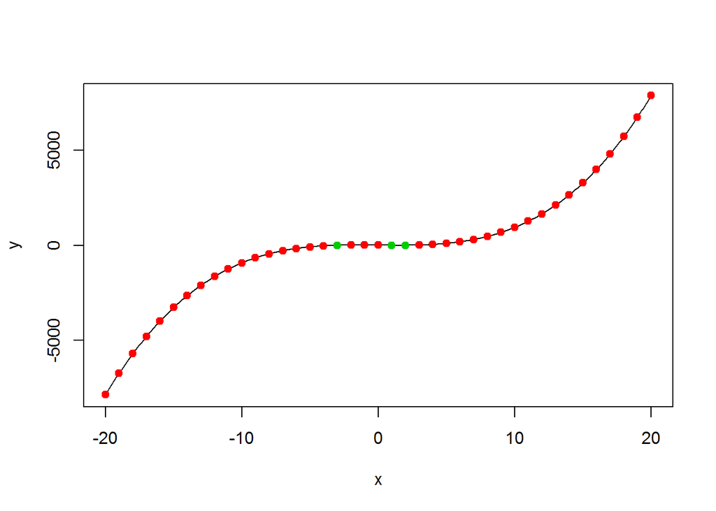

```r
minv <- -20
maxv <- 20
x <- seq(from=minv,to=maxv,length=1000)
y <- x^3-7*x+9
plot(x,y,type="l")
ns <- minv:maxv
z <- ns^3-7*ns+9

TorF <- is_prime(z)
points(ns,z,col=TorF+2,pch=20,cex=1.5)
```

# 3 $\alpha$ は$0 < \alpha \le \frac{\pi}{2}$ を満たす定数とし、四角形ABCDに関する次の2つの条件を考える。

1. 四角形ABCDは半径1の円に内接する
2. 角 ABC = 角 DAB = $\alpha$

条件(i)と(ii)を満たす四角形のなかで、4辺の長さの積

$$k = AB \cdot BC \cdot CD \cdot DA$$

が最大となるものについて、kの値を求めよ

A,B,C,Dの座標は

$(\cos{-\theta},\sin{-\theta})$ $(\cos{\theta},\sin{\theta})$ $(\cos{\pi-\phi},\sin{\pi-\phi})$ $(\cos{\pi+\phi},\sin{\pi+\phi})$

ただし、$\theta > 0$, $\phi > 0$、$\pi -\phi > \theta$

$\alpha = (\frac{\pi}{2} -\theta) + \frac{\theta+\phi}{2}$

と表せる。

$\bar{AB} = 2 \sin{\theta}$, $\bar{BC}= \bar{DA} = 2 /cos{\frac{\theta+\phi}{2}}$, $\bar{CD} = 2 \sin{\phi}$なので、

$k = 2 \sin{\theta} \times (2 /cos{\frac{\theta+\phi}{2}})^2 \times 2 \sin{\phi}$

ある$\alpha$の値について、適当に４点を取ってみる。

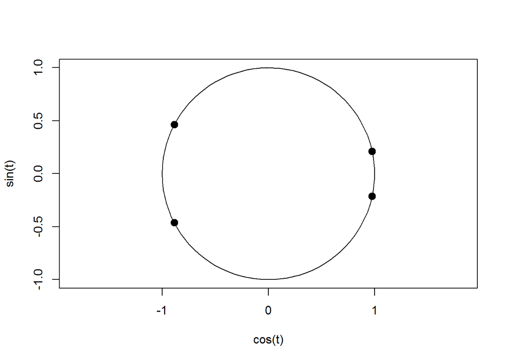

```r
alpha <- runif(1) * pi/2
#alpha <- pi/4
theta <- runif(1) * pi
phi <- 2*(alpha -pi/2 + theta/2)

x <- c(cos(-theta),cos(theta),cos(pi-phi),cos(pi+phi))
y <- c(sin(-theta),sin(theta),sin(pi-phi),sin(pi+phi))

t <- seq(from=0,to=2*pi,length=100)
plot(cos(t),sin(t),type="l",asp=TRUE)
points(x,y,pch=20,cex=2)
```

```r
# 角度の検算
AB <- c(x[1]-x[2],y[1]-y[2])
CB <- c(x[3]-x[2],y[3]-y[2])
sum(AB*CB)/sqrt(sum(AB^2)*sum(CB^2))
```

```
## [1] 0.339972
```

```r
cos(alpha)
```

```
## [1] 0.339972
```

kの値を最大にする$\theta$を探してみる。

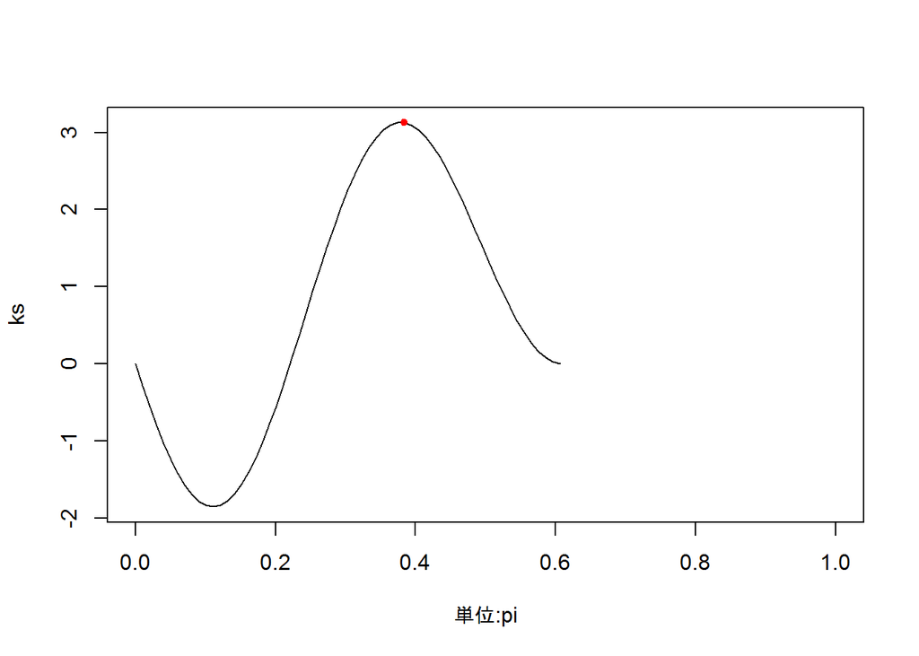

```r
theta <- seq(from=0,to=pi,length=100)
phi <- 2*(alpha -pi/2 + theta/2)

oks <- pi-phi > theta

theta <- theta[oks]
phi <- phi[oks]

ks <- 2^4 * sin(theta) * cos((theta+phi)/2)^2 * sin(phi)
max.k <- which(ks==max(ks))
plot(theta/pi,ks,type="l",xlab="単位:pi",xlim=c(0,1))
points(theta[max.k]/pi,ks[max.k],pch=20,col=2)
```

```r
ks[max.k]
```

```
## [1] 3.124933
```

```r
4*sin(alpha)^4 #解析的答え
```

```
## [1] 3.128788
```

# 4 コインをn回投げて複素数 $z_i,z_2,...,z_n$を次のように定める

1. 1回目に表が出れば$z_1=\frac{-1+\sqrt{3} i}{2}$とし、裏が出れば、$z_1=1$とする
2. k=2,3,…,n のとき、k回目に表が出れば$z_k0\frac{-1+\sqrt{3}i}{2}z_{k-1}$とし、裏が出れば、$z_k = \bar{z_{k-1}}$とする。ただし、$\bar{z_{k-1}}$は$z_{k-1}$の共役複素数である

このとき、$z_n=1$となる確率を求めよ

このコインで表が出る確率をpとして、シミュレーションする

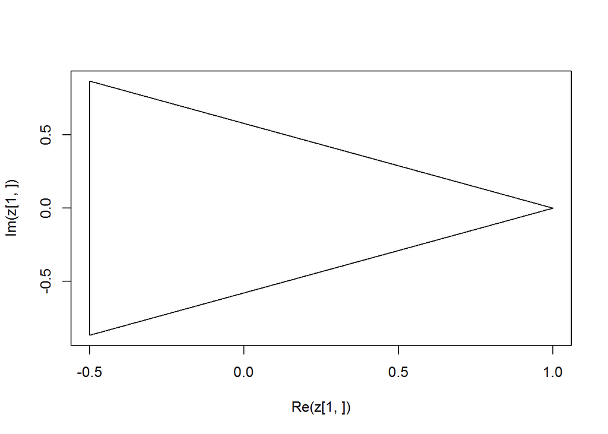

```r
n <- 20
# k回繰り返す
k <- 100000
p <- 0.5
omoteUra <- matrix(sample(0:1,n*k,replace=TRUE,prob=c(p,1-p)),nrow=k)

z <- matrix(0,k,n)
a <- (-1+3^0.5* 1i)/2

for(i in 1:k){
  if(omoteUra[i,1]==0){
    z[i,1] <- a
  }else{
    z[i,1] <- 1
  }
  for(j in 2:n){
    if(omoteUra[i,j]==0){
      z[i,j] <- z[i,j-1]*a
    }else{
      z[i,j] <- Conj(z[i,j-1])
    }
  }
}
plot(z[1,],type="l")
```

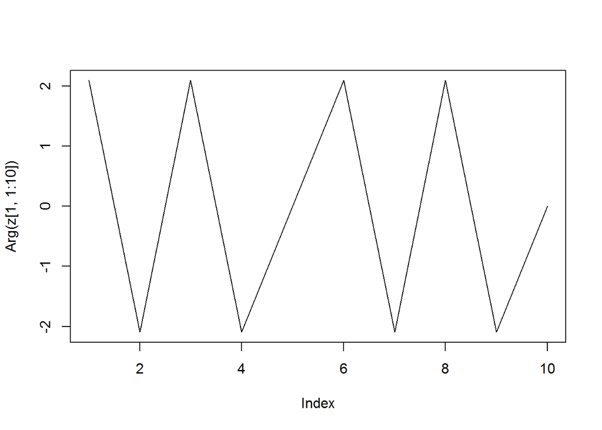

```r
plot(Arg(z[1,1:10]),type="l")
```

k施行のうち、1の割合を調べる

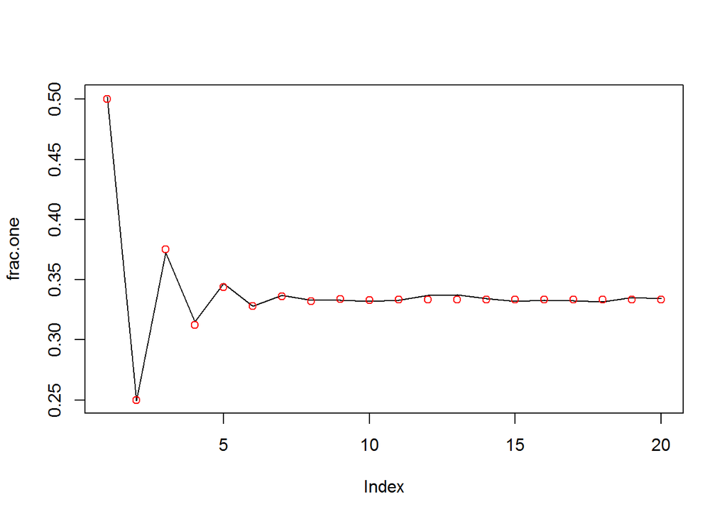

```r
# 1との一致を調べると、計算誤差のせいでうまくカウントできないのでちょっと工夫する
one <- (Re(z)-1)^2 < 0.0001
frac.one <- apply(one,2,mean)
plot(frac.one,type="l")
points(1/3+1/6*(-1/2)^(1:n-1),col=2) # 解析的答え
```

# 5 曲線$y=\log{x}$上の点A $(t,\log{t})$における法線に、点BをAB=1となるようにとる。ただしBのx座標はtよりも大きいとする

1. 点Bの座標(u(t),v(t))を求めよ。また、$(\frac{d u}{dt},\frac{dv}{dt})$を求めよ
2. 実数rは$0 < r < 1$を満たすとし、tがrから1まで動くときに点Aと点Bが描く曲線の長さをそれぞれ$L_1(r),L_(r)$とする。このとき、極限$lim_{r \to +0} (L_1(r) - L_2(r))$を求めよ

$(t,\log{t})$における接線の傾きは、$\frac{1}{t}$

したがって、Bは$(t + \frac{\frac{1}{t}}{\sqrt{1+\frac{1}{t^2}}},\log{t} + \frac{-1}{\sqrt{1+\frac{1}{t^2}}})$

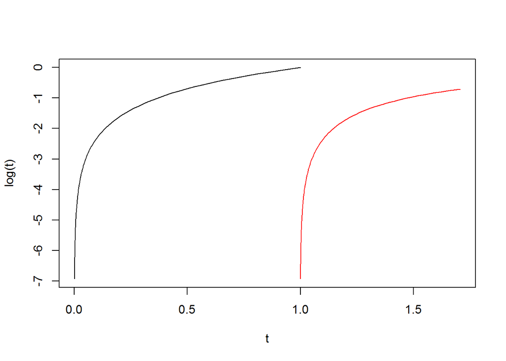

```r
#t <- seq(from=0,to=1,length=100)
#t <- t[-1]
t <- 2^seq(from=-10,to=0,length=100)


ut <- t + (1/t)/(sqrt(1+1/t^2))
vt <- log(t) + (-1)/sqrt(1+1/t^2)
plot(t,log(t),type="l",xlim=range(c(t,ut)),ylim=range(c(log(t),vt)))
points (ut,vt,type="l",col=2)
```

曲線の長さを折れ線の和とすることにする。

折れ線線分ごとに長さを出し、その逆順をとり、累積和を計算してプロットする。

プロットの右方向の極限が、求める答え

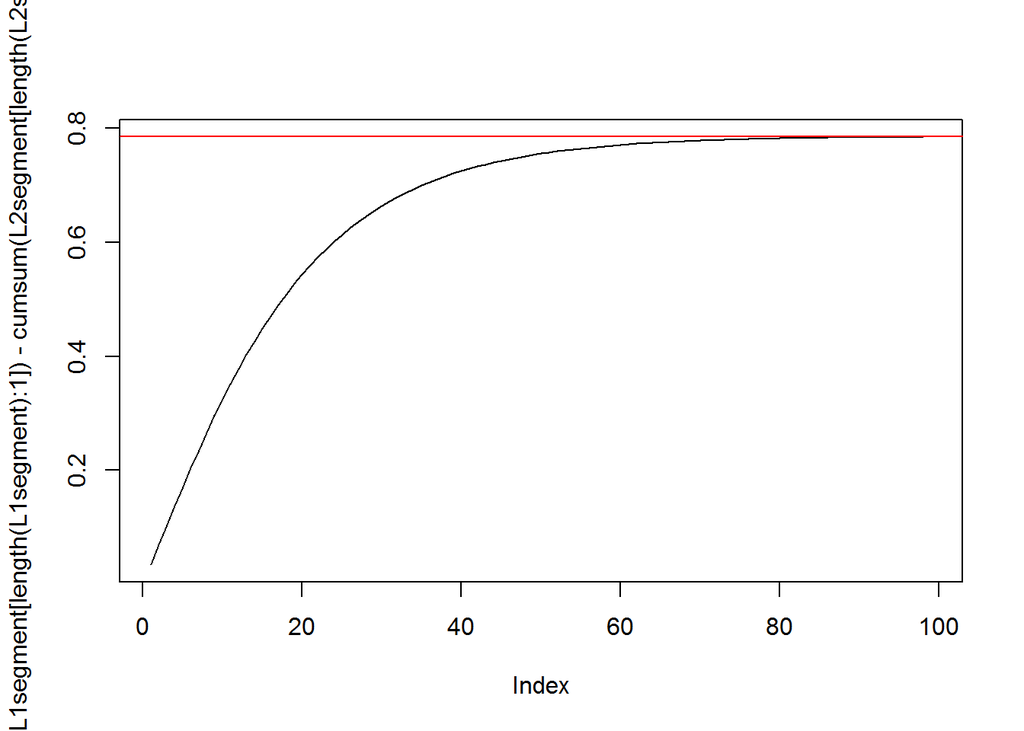

```r
L1segment <- sqrt(diff(t)^2 + diff(log(t))^2)
L2segment <- sqrt(diff(ut)^2 + diff(vt)^2)

plot(cumsum(L1segment[length(L1segment):1])-cumsum(L2segment[length(L2segment):1]),type="l")
abline(h=pi/4,col=2) # 解
```

# 6 四面体 ABCDはAC=BD, AD = BCを満たすとし、辺ABの中点をP,辺CDの中点をQとする

1. 辺ABと線分PQは垂直であることを示せ
2. 線分PQを含む平面$\alpha$で四面体ABCDを切って2つの部分に分ける。このとき、2つの部分の体積は等しいことを示せ

Pを原点にとり、A,Bをそれぞれ(-1,0,0),(1,0,0)とする。

三角形ABDと三角形BACは３辺の長さが等しい。

Cをxy平面上のy>0の半面に取る$(r\cos{\theta},r\sin{\theta},0);r>0,0 < \theta < \pi$。

Dは$(-r\cos{\theta},r\sin{\theta},0);r>0,0 < \theta < \pi$ をx軸上に回転した点であるので

$(-r\cos{\theta},r\sin{\theta}\cos{\phi},r\sin{\theta}\sin{\phi})$

```r
P <- c(0,0,0)
A <- c(-1,0,0)
B <- c(1,0,0)
r <- runif(1)*5
theta <- runif(1)*pi
C <- r * c(cos(theta),sin(theta),0)
phi <- runif(1)*2*pi
D<- c(-r*cos(theta),r*sin(theta)*cos(phi),r*sin(theta)*sin(phi))
Q <- (C+D)/2

library(rgl)
```

```r
plot3d(rbind(A,B,C,D,P,Q))
segments3d(rbind(A,B))
segments3d(rbind(A,D))
segments3d(rbind(A,C))
segments3d(rbind(B,C))
segments3d(rbind(B,D))
segments3d(rbind(C,D))
segments3d(rbind(P,Q),color=2)
```

垂直を確認する

```r
sum((A-B)*(P-Q))
```

```
## [1] 0
```

```r
sum((C-D)*(P-Q))
```

```
## [1] 3.469447e-18
```

切断面 $\alpha$は$x=0$になっている

```r
Q
```

```
## [1]  0.0000000  0.4200674 -0.1208923
```